# Joins

Rarely do we work on only one `data.frame`, particularly when we start working with complex data and data contained within relational databases. In these cases, data are factored into several tables (akin to `data.frame` objects) with entries that connect the information from one table to another. Consider the following example tables

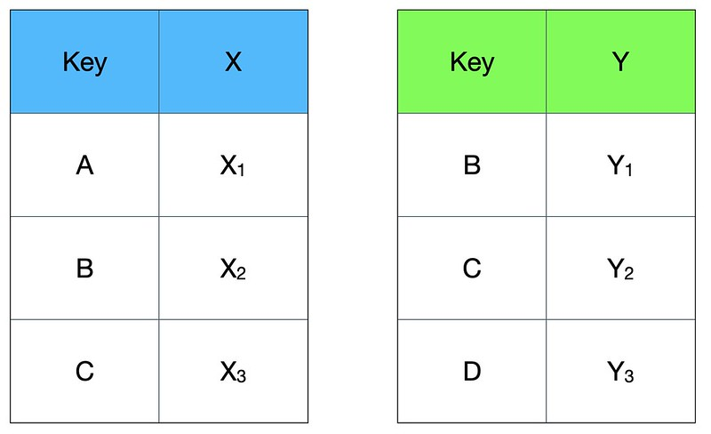

Example data table structure

Each has a column I named *Key* and another with some data in it. In `R` they could be defined as:

```r
df.X <- data.frame( Key = c("A","B","C"),
                    X = c(1,2,3) )
df.X
```

```
  Key X
1   A 1
2   B 2
3   C 3
```

and

```r
df.Y <- data.frame( Key = c("B","C","D"),
                    Y = c(10,11,12) )
df.Y
```

```
  Key  Y
1   B 10
2   C 11
3   D 12
```

## Keys

An important component of relational data are the *keys*. These are unique identifiers for a particular datum from a table. In each of these examples the variable (obviously named) `Key` is what is called a *Primary Key* because it uniquely identifies each row. You can verify this by counting the number of entries then filtering only for ones with 2 or more instances.

```r
library( tidyverse )
df.X %>%
  count( Key ) %>%
  filter( n > 1 )
```

```
[1] Key n
<0 rows> (or 0-length row.names)
```

Notice there is nothing here as each is unique.

The keys are used to link together different tables.

# Joins

> A *join* is where we combine information contained within two data frames.  
> Joins are ways to merge together data and come in four flavors.

## Left Join

A *left join* is one where all the data from the left data frame is in the result and the data whose keys in the right data frame are present in the left one are also included. Graphically, this leads to:

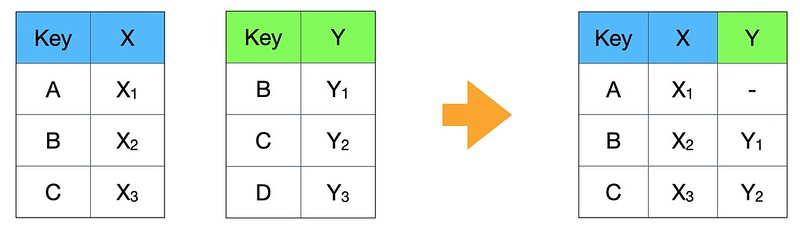

left join

Where in `R` we do this using the `left_join()` function.

```r
df.X %>%
  left_join( df.Y, by="Key")
```

```
  Key X  Y
1   A 1 NA
2   B 2 10
3   C 3 11
```

## Right Join

The right join does the same thing but keeps all the keys in the right data table and has missing data where the key in the left one is not in the right one.

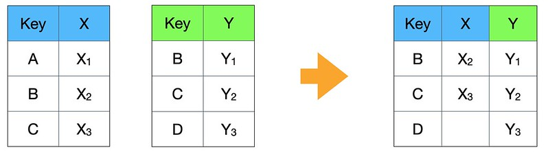

Right Join

This is accomplished using the `right_join()` function.

```r
df.X %>%
  right_join( df.Y, by="Key")
```

```
  Key  X  Y
1   B  2 10
2   C  3 11
3   D NA 12
```

## Full (or Outer) Join

This join is one where all the keys are retained adding missing data as necessary.

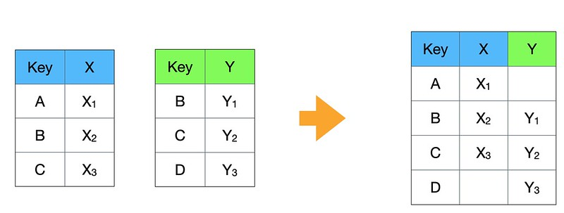

Outer Join

```r
df.X %>%
  full_join( df.Y, by="Key")
```

```
  Key  X  Y
1   A  1 NA
2   B  2 10
3   C  3 11
4   D NA 12
```

## Inner Join

The last one retains *only* those keys that are common in both.

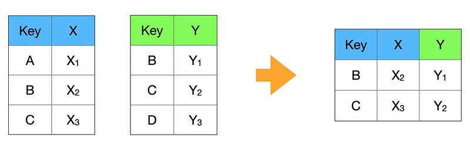

Inner Join

```r
df.X %>%
  inner_join( df.Y, by="Key")
```

```
  Key X  Y
1   B 2 10
2   C 3 11
```

# Filtering Joins

We can also use joins to filter values within one `data.frame`. Here the `semi_join()` keeps everything in the left data that has a key in the right one, but **importantly** it does not import the right data columns into the result.

```r
df.X %>%
  semi_join( df.Y )
```

```
  Key X
1   B 2
2   C 3
```

The opposite of this is the `anti_join()` which drops everything in the left table that has a key in the right one, leaving only the ones that are unique.

```r
df.X %>%
  anti_join( df.Y )
```

```
  Key X
1   A 1
```

## Questions

If you have any questions for me specifically on this topic, please post as an Issue in your repository, otherwise consider posting to the discussion board on [Canvas](https://canvas.vcu.edu).